#Лабораторный практикум ВКИАД c R

**Преподаватель**

```
Дернакова Оксана Владимировна
```

**Студент**

```
Шапиро Игорь Александрович, 2 курс, 6 группа, ПМ
```

**Вариант № 10**

### Часть 1. Управление данными в R

Загрузка данных из текстового файла в таблицу данных

```r
qc <- read.table("QC10.txt")
```

Размерность таблицы данных

```r
print(dim(qc))
```

```
## [1] 100   9
```

Первые 3 записи таблицы

```r
head(qc,3)
```

```
##      V1    V2 V3 V4 V5 V6    V7     V8 V9
## 1 61.39 56.08  4  2  1  4 5.290 47.685  5
## 2 63.80 57.00  1  3  1  2 4.500 46.800  5
## 3 61.59 56.93  5  1  2  4 5.285 51.330  5
```

Таблица после переименования переменных

```r
names(qc) <- c("c1","c2", "kit", "nbug", "maker", "vendor", "c3", "c4", "bug")
head(qc)
```

```
##      c1    c2 kit nbug maker vendor    c3     c4 bug
## 1 61.39 56.08   4    2     1      4 5.290 47.685   5
## 2 63.80 57.00   1    3     1      2 4.500 46.800   5
## 3 61.59 56.93   5    1     2      4 5.285 51.330   5
## 4 58.89 53.70   3    0     1      2 4.455 49.605   3
## 5 59.17 53.83   4    1     1      1 4.845 53.235   4
## 6 62.15 54.80   0    1     1      4 5.845 48.510   9
```

Комплексная статистика по переменной vendor

```r
summary(qc$vendor)
```

```
##    Min. 1st Qu.  Median    Mean 3rd Qu.    Max.
##    1.00    1.75    2.00    2.49    4.00    4.00
```

Комплексная статистика по переменной vendor после ее преобразования в переменную-фактор

```r
summary(as.factor(qc$vendor))
```

```
##  1  2  3  4
## 25 28 20 27
```

Количество изделий, у которых число некритических дефектов больше 3

```r
sum(qc$nbug > 3)
```

```
## [1] 11
```

Наблюдения, для которых количество некритических дефектов равно максимальному

```r
qc[qc["nbug"] == max(qc$nbug),]
```

```
##       c1    c2 kit nbug maker vendor    c3     c4 bug
## 15 60.02 53.93   3    6     2      1 5.080 47.535   2
## 72 63.10 57.19   7    6     1      1 4.925 45.405   3
```

### Часть 2. Описательная статистика и графический анализ

Присоединение таблицы данных к списку текущих переменных и загрузка дополнительной библиотеки

```r
attach(qc)
library("e1071")
```

Выборочные среднее и медиана для переменной с1 в указанном порядке

```r
mean(c1)
```

```
## [1] 60.9134
```

```r
median(c1)
```

```
## [1] 60.9
```

Выборочные квартили Q1, Q2, Q3 и интерквартильный размах для c1

```r
quantile(c1, probs = c(0.25,0.50,0.75))
```

```
##     25%     50%     75%
## 59.1775 60.9000 62.2925
```

```r
IQR(c1)
```

```
## [1] 3.115
```

Комплексная статистика по переменной c1

```r
summary(c1)
```

```
##    Min. 1st Qu.  Median    Mean 3rd Qu.    Max.
##   55.06   59.18   60.90   60.91   62.29   66.54
```

Дисперсия для переменной с1 и переменной 2 * с1 + 100

```r
var(c1)
```

```
## [1] 5.880716
```

```r
var(2 * c1 + 100)
```

```
## [1] 23.52286
```

```r
sprintf("Вывод: отношение дисперсий равно %f", var(2 * c1 + 100) / var(c1))
```

```
## [1] "Вывод: отношение дисперсий равно 4.000000"
```

Дисперсия для переменной с1, полученная с помощью векторного выражения

```r
(sum((c1 - mean(c1))^2)) / (length(c1) - 1)
```

```
## [1] 5.880716
```

Гистограмма для переменной с1

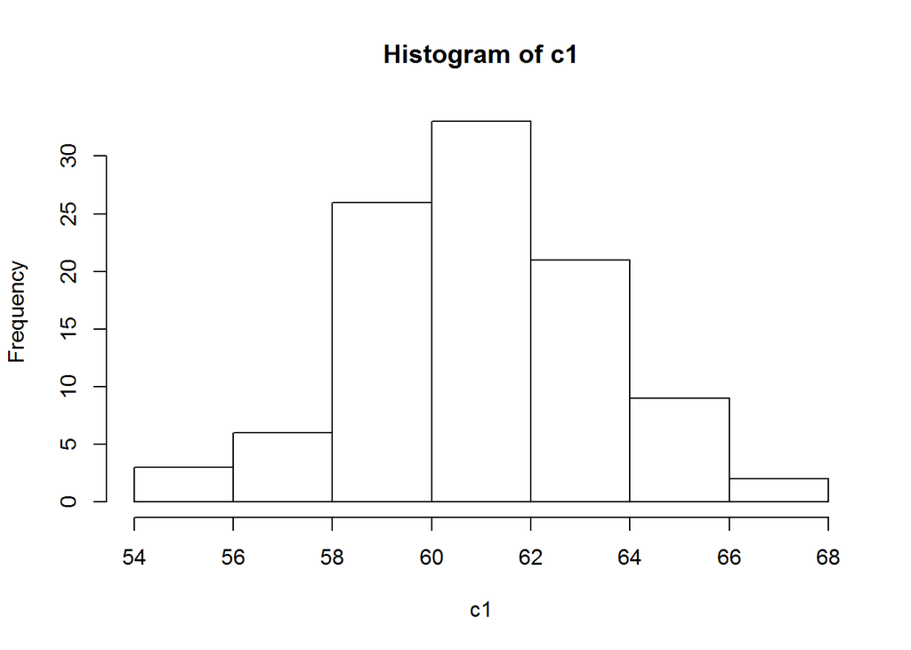

```r
hist(c1)
```

Асимметрия и эксцесс для переменной c1 в указанном порядке

```r
skewness(c1)
```

```
## [1] 0.06109714
```

```r
kurtosis(c1)
```

```
## [1] -0.3512945
```

Проверка распределения переменной c1 на нормальность с помощью статистического теста Лиллиефорса

```r
library(nortest)
lillie.test(c1)
```

```
##
##  Lilliefors (Kolmogorov-Smirnov) normality test
##
## data:  c1
## D = 0.054421, p-value = 0.6607
```

**Вывод:** Гипотеза о нормальном распределении принимается на уровне значимости 0.05.

### Часть 3. Анализ статистических зависимостей

Перекодирование переменной kit так, чтобы она принимала только два значения: 1 и 2

```r
kit <- ifelse(kit < 3, 1, 2)
```

Ранговый коэффициент корреляции Спирмена для переменных kit и maker.

```r
cor(kit, maker, method = "spearman")
```

```
## [1] 0.08173077
```

Таблица сопряженности по переменным kit и maker

```r
table(kit,maker)
```

```
##    maker
## kit  1  2
##   1 27 21
##   2 25 27
```

**Выывод:** Согласно ранговому коэффициенту, близкому к 0, и таблице сопряженности согласованность между переменными практически отсутствует.

Коэффициент корреляции Для переменных c1, c3.

```r
cor.test(c1,c3)
```

```
##
##  Pearson's product-moment correlation
##
## data:  c1 and c3
## t = 5.8081, df = 98, p-value = 7.836e-08
## alternative hypothesis: true correlation is not equal to 0
## 95 percent confidence interval:
##  0.3437945 0.6389502
## sample estimates:
##       cor
## 0.5060409
```

**Вывод:** Гипотеза о равенстве нулю коэффициента корреляции между переменными отклоняется на уровне значимости 0.05 (p-value < 0.05).

Корреляционная матрица для числовых характеристик с1-c4

```r
myCor <- cor(qc[c("c1","c2","c3","c4")])
print(myCor)
```

```
##            c1         c2          c3          c4
## c1  1.0000000  0.9045418  0.50604092 -0.19607400
## c2  0.9045418  1.0000000  0.38674144 -0.20389934
## c3  0.5060409  0.3867414  1.00000000 -0.09152175
## c4 -0.1960740 -0.2038993 -0.09152175  1.00000000
```

Матрица корреляции в удобном представлении

```r
symnum(myCor)
```

```
##    c1 c2 c3 c4
## c1 1
## c2 *  1
## c3 .  .  1
## c4          1
## attr(,"legend")
## [1] 0 ' ' 0.3 '.' 0.6 ',' 0.8 '+' 0.9 '*' 0.95 'B' 1
```

**Вывод:** Наибольший коэффициент корреляции наблюдается между переменными c1 и c2.

Построение регрессионной модели по переменным c1 (зависимая - отклик) и c2 (независимая - фактор) и вывод общей статистики по результатам оценивания

```r
linmond = lm(formula = c1 ~ c2)
summary(linmond)
```

```
##
## Call:
## lm(formula = c1 ~ c2)
##
## Residuals:
##      Min       1Q   Median       3Q      Max
## -2.46433 -0.64486 -0.04164  0.58828  2.32865
##
## Coefficients:
##             Estimate Std. Error t value Pr(>|t|)
## (Intercept)  4.77846    2.67499   1.786   0.0771 .
## c2           1.01962    0.04855  21.001   <2e-16 ***
## ---
## Signif. codes:  0 '***' 0.001 '**' 0.01 '*' 0.05 '.' 0.1 ' ' 1
##
## Residual standard error: 1.039 on 98 degrees of freedom
## Multiple R-squared:  0.8182, Adjusted R-squared:  0.8163
## F-statistic:   441 on 1 and 98 DF,  p-value: < 2.2e-16
```

**Вывод:**Значим (на уровне 0.05) только коэффициент при с2. Статистика R-квадрат принимает значение 0.8182.

Диаграмма рассеяния с линией регрессии для переменных c1 и c2

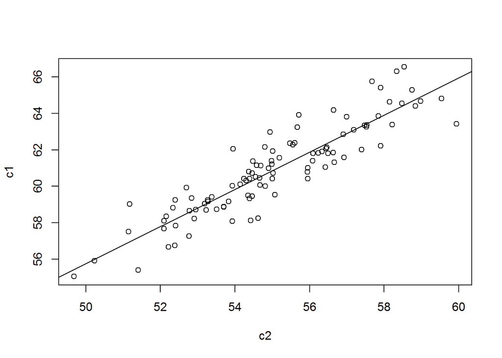

```r
plot(c1~c2)
abline(linmond)
```

Коэффициенты регрессионной модели

```r
coefficients(linmond)
```

```
## (Intercept)          c2
##    4.778455    1.019618
```

График “Квантиль-квантиль” для остатков модели

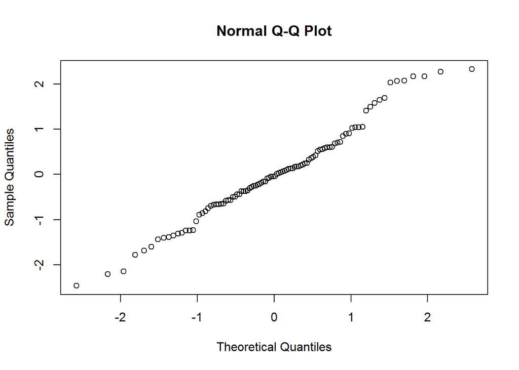

```r
res = residuals(linmond)
qqnorm(res)
```

**Вывод**: Большинство точек располагаются вблизи прямой линии, поэтому распределение остатков близко к нормальному.

Тест Колмогорова-Смирнова на нормальность остатков

```r
ks.test(res, pnorm, mean(res), sd(res))
```

```
##
##  One-sample Kolmogorov-Smirnov test
##
## data:  res
## D = 0.073138, p-value = 0.6586
## alternative hypothesis: two-sided
```

**Вывод**: Критерий принимает гипотезу о нормальном распределении остатков на уровне значимости 0.05(p-value > 0.05).

### Часть 4. Анализ неоднородных данных

Частоты значений для переменной maker.

```r
table(maker)
```

```
## maker
##  1  2
## 52 48
```

Двухвыборочный t-критерий по переменной, для которой наблюдается значимое различие средних в двух подвыборках (по значениям переменной maker), c разбиением на подвыборки по переменной maker

```r
test1 = t.test(c1 ~ maker)
test2 = t.test(c2 ~ maker)
test3 = t.test(c3 ~ maker)
test4 = t.test(c4 ~ maker)
min = min(c(test1$p.value, test2$p.value, test3$p.value, test4$p.value))
if (test1$p.value == min) test1
if (test2$p.value == min) test2
if (test3$p.value == min) test3
if (test4$p.value == min) test4
```

```
##
##  Welch Two Sample t-test
##
## data:  c4 by maker
## t = -5.036, df = 95.109, p-value = 2.253e-06
## alternative hypothesis: true difference in means is not equal to 0
## 95 percent confidence interval:
##  -2.913325 -1.265857
## sample estimates:
## mean in group 1 mean in group 2
##        48.03635        50.12594
```

**Вывод:** Гипотеза о равенстве средних в двух подвыборках отклоняется на уровне значимости 0.05 (p-value < 0.05) для переменной c4 (средние значения характеристики c4 у двух производителей статистически различимы).

“Ящики с усами” для переменной c4 в разрезе по номеру производителя.

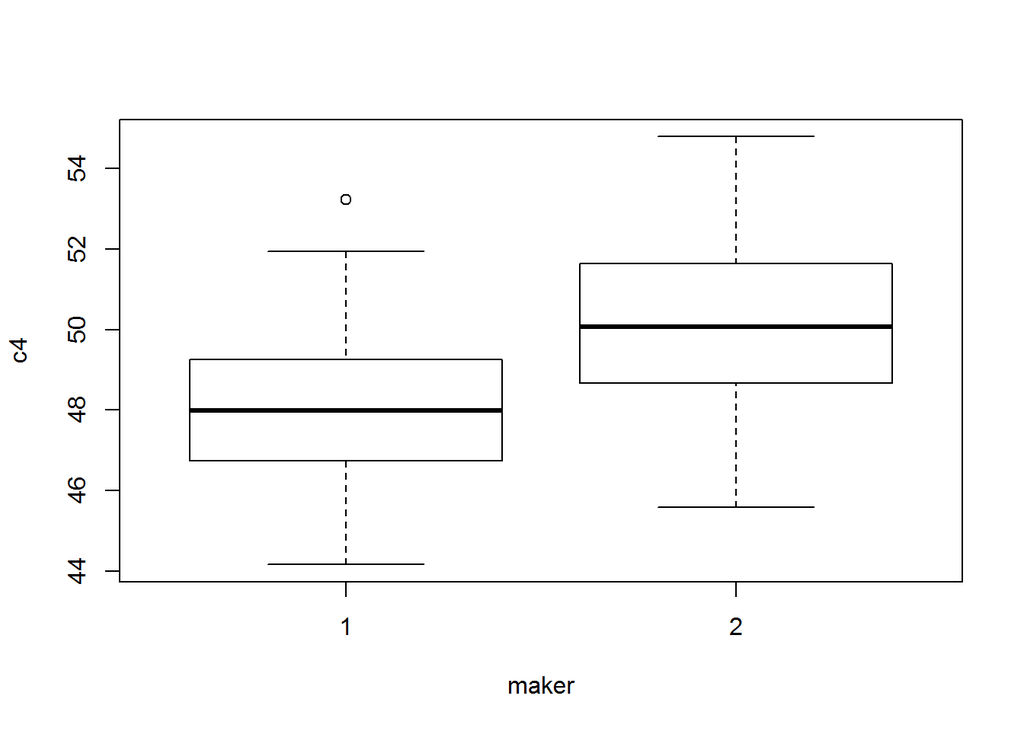

```r
boxplot(c4~maker)
```

График ядерной оценки плотности распределения для переменной c4

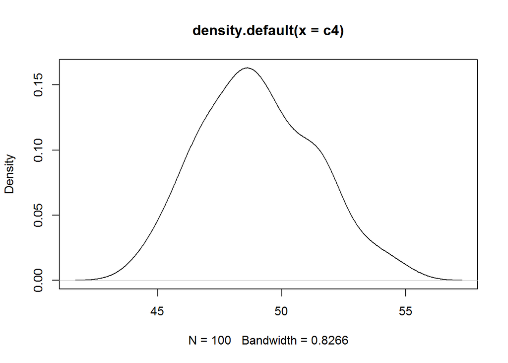

```r
plot(density(c4))
```

**Вывод:** Из графика видно, что выборка описывается моделью, которая представляет собой смесь двух распределений.

### Часть 5. Классификация неоднородных данных

Диаграмма рассеяния переменных c3 и c4, для которых коэффициент корреляции принимает наиболее близкое к нулю значение

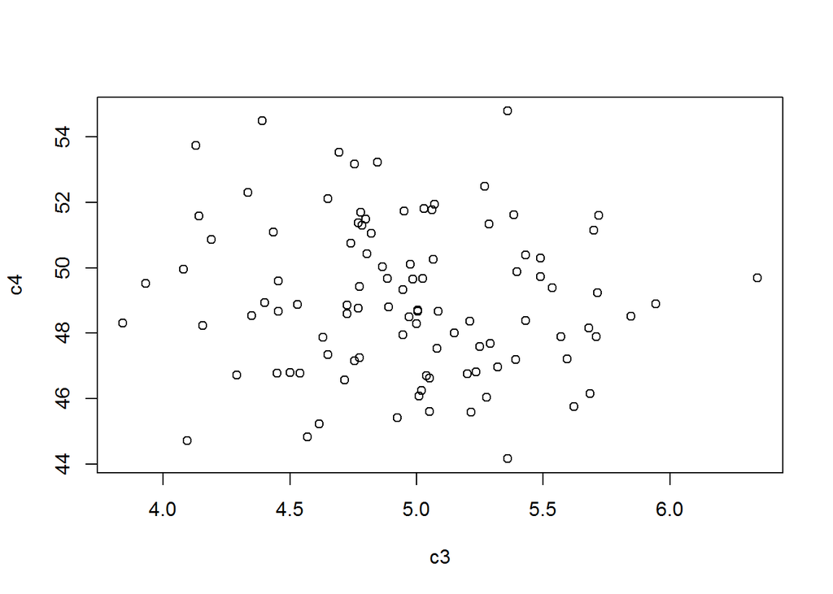

```r
plot(c4~c3)
```

Первые 3 строки матрицы из переменных c3 и c4

```r
matr = cbind(c3,c4)
head(matr,3)
```

```
##         c3     c4
## [1,] 5.290 47.685
## [2,] 4.500 46.800
## [3,] 5.285 51.330
```

Применение кластерного анализа и вывод частот наблюдений в каждом оцененном классе

```r
kmres = kmeans(matr,2)
table(kmres$cluster)
```

```
##
##  1  2
## 44 56
```

График с классовой принадлежностью наблюдений

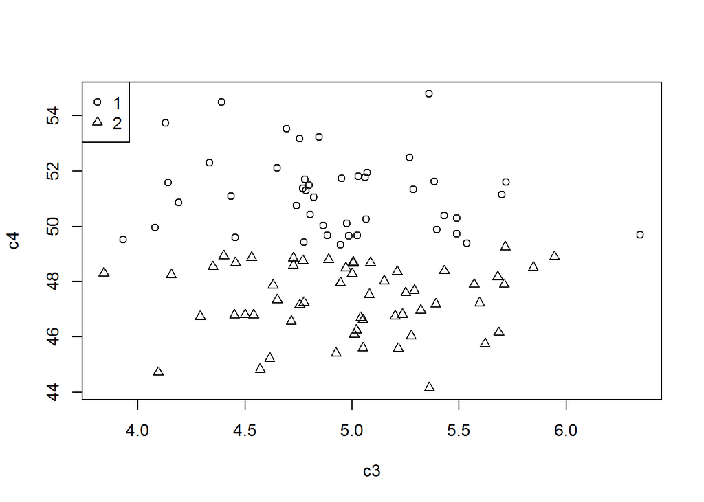

```r
plot(c4~c3, pch = ifelse(kmres$cluster == "1", 1,2))
legend("topleft", legend = c("1","2"), pch = c(1,2))
```

Работа с данными закончена

```r
detach(qc)
```